# Inference 2 - Hypothesis Testing

## Introduction

This section covers a fundamental part of inference: hypothesis testing.

Tests of hypotheses are frequently applied in econometrics, e.g. t-tests for OLS parameters or in tests for heteroscedasticity.

In this section we will:

- Take a look at the general hypothesis testing procedure
- Derive hypothesis testing with a simulation
- Learn how to do hypothesis testing in R

## Introduction

- In the previous part I assumed that we know the population. Actually – in practice – we don't
- We use hypothesis testing because we don't much about our populations.

**We actually don't know**:

- The population mean \(\mu_X\) (our parameter of interest)
- The population variance \(\sigma^2_X\) and standard deviation \(\sigma_X\)
- The true distribution of the population \(X \sim ?(?)\)

## Introduction

In this scenario (which is the realistic scenario) we do the following:

1. **Assume the population distribution and a value for our parameter of interest**
2. **Then estimate the unknown parameters from a sample**
3. **Test if our assumptions are reasonable**

## Formal Hypothesis Testing Procedure

Assume that the distribution of the population is normal (e.g. because it is reasonably from theory)

1. Formulate a hypothesis about our population parameter (e.g. \(H_0:\mu_X = 1000\)) 1.1 Also the alternative hypothesis \(H_1: \mu_X \neq 1000\)
2. Estimate the parameter
   - In this case with the arithmetic mean \(\bar{X}\)
3. Estimate the variance and derive the sample standard deviation \(S_X\)
4. Standardise \(\bar{X}\) using our estimated \(S_X\) and the assumed \(\mu_X\)
5. Calculate the probability that our observed \(\bar{X}\) is from the population, given a specific level of certainty (e.g. \(95 \%\))

## Simulated Population

We take again our sample from a simulated population of ZU student income:

```r
library(ggplot2)
library(tidyverse)
set.seed(11) # seed for reproducibility

n <- 1200
inc_2 <- rnorm(n, mean = 1000, sd = 200)
```

## Simulated Population

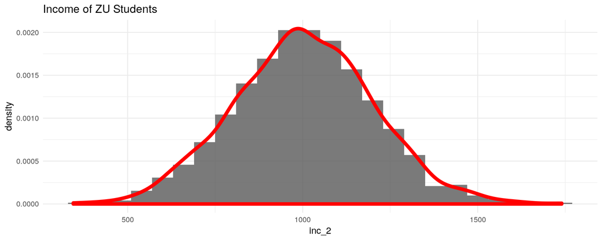

## Sample

We draw a random sample with size `50` from our population:

```r
set.seed(24) ;   sample_n <- 50
sample_2 <- sample(x = inc_2, size = sample_n, replace = F)
```

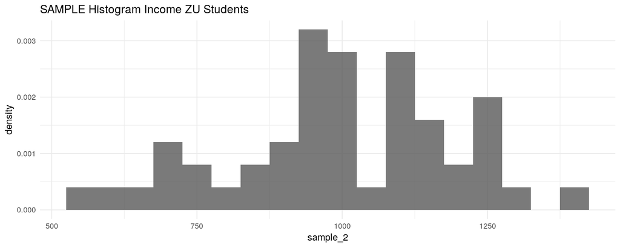

## 1. Formulate the Null-Hypothesis that mean student income is less then \(940 €\):

\[ H_0 : \mu_{inc} < 940 \] Which leaves us with the alternative Hypothesis that the mean income is more or equal to \(940€\): \[ H_1: \mu_{inc} \geq 940 \]

```r
mu_inc = 940
mu_inc
```

```
## [1] 940
```

## 2. Estimate the mean with the sample mean \(\bar{X}\) :

```r
inc_bar <- mean(sample_2)
inc_bar
```

```
## [1] 998.3979
```

## 3. Estimate the sampling variance \(S^2_{inc}\) and derive the sampling standard deviation \(S_{inc}\) :

```r
var(sample_2)
```

```
## [1] 37190.76
```

```r
S_inc <- sd(sample_2)
S_inc
```

```
## [1] 192.8491
```

## Estimated Distribution

At this state we would expect our sample mean to be distributed like this:

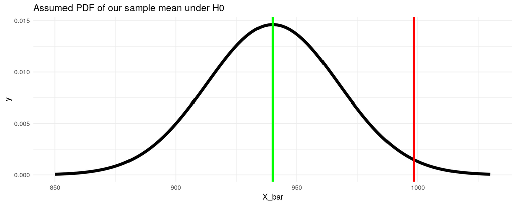

Note that we used the *assumed* mean ZU student income \(\mu_{inc} =940€\) (green line). If our \(H_0\) would be true, this would be our estimator distribution.

## 4. Standardise \(\bar{X}\) to calculate probabilities

```r
Z_inc_bar <- (inc_bar - mu_inc) / (S_inc / sqrt(sample_n)) ; Z_inc_bar
```

```
## [1] 2.141236
```

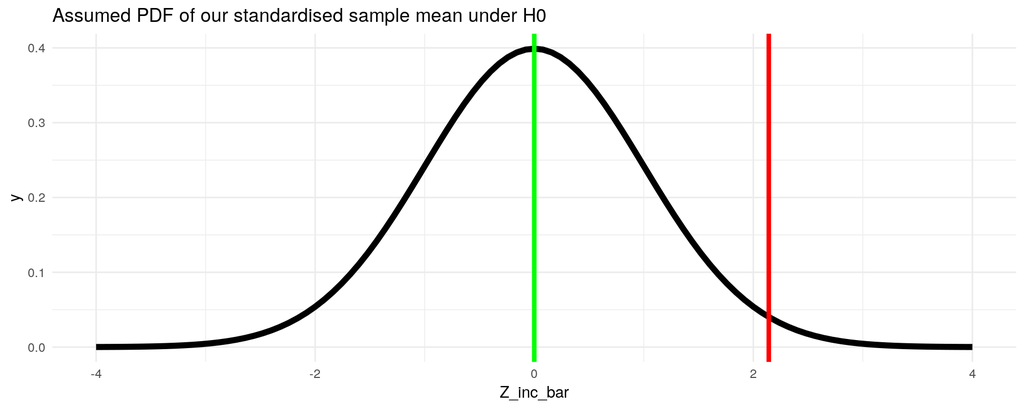

## 5. Calculate probability of \(\bar{X}\) occuring at 5% significance level

Look up \(z-value\) for \(1-5\% = 95\%\), e.g. in this [table](http://www.z-table.com/). \(z_{95\%} \approx 1.65\)

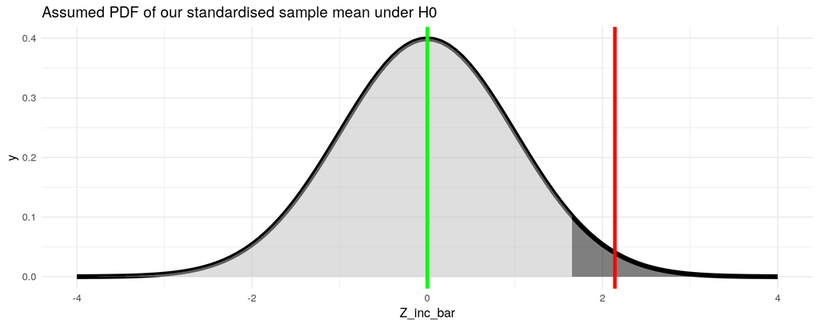

## Hypothesis Test

Check whether our standardised estimator \(Z_{\bar{inc}}\) is larger than our critical value \(c\).

- Critical value \(c\): quantile of the standard normal cdf with \(P(Z_{bar{inc}} > c) = 95 \%\)
- Test statistic: our standardised estimator

Remember our \(H_0: \mu_{inc} < 940€\) and \(H_1: \mu_{inc} \geq 940€\). Lets test that in R:

```r
Z_inc_bar >= qnorm(0.95)
```

```
## [1] TRUE
```

## Hypothesis Test - Other Variants

What we did was only the *right-sided* hypothesis test.

We could also test other hypotheses:

- Left-sided: \(H_0: \mu_{inc} > 940€\) and \(H_1: \mu_{inc} \leq 940€\)
  - \(\mu_{inc} \leq c\)
- Both-sided: \(H_0: \mu_{inc} = 940€\) and \(H_1: \mu_{inc} \neq 940€\)
  - \(|\mu_{inc}| > c\)

## P-Values

So called *p-values* are often used and reported in statistical work. They indicate the highest level of significance at which we can reject the \(H_0\).

In our example, we could not only reject the \(H_0\) at the \(5\%\) level, but also at the \(2.5\%\) level:

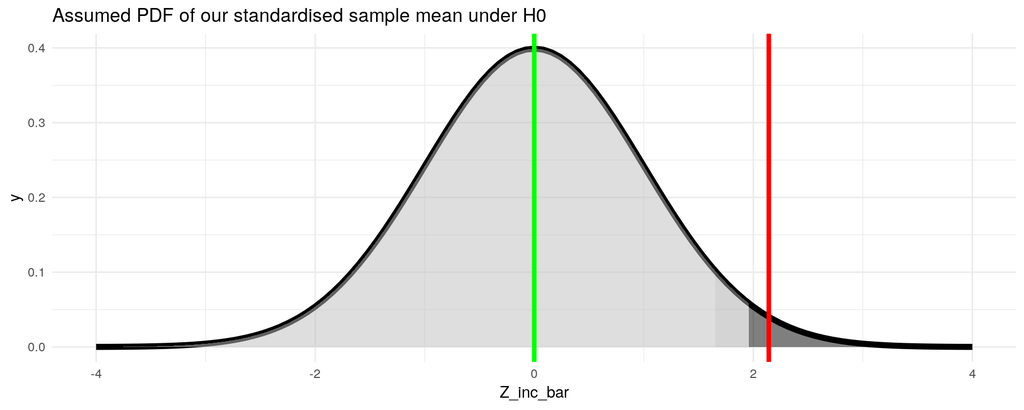

## P-Values

But at most, we could reject it at the level of our test-statistic. So we just need to look up the corresponding value for \(Z_\bar{inc}\) in the [z- table](http://www.z-table.com/), or with r:

```r
1- pnorm(Z_inc_bar)
```

```
## [1] 0.01612751
```

This is our p-value. It tells us that we can reject the \(H_0\) at most at a significance level of \(\approx 1.6 \%\).

## Excercise 1

- Simulate a normally distributed population with \(\mu = 5000\), \(\sigma = 450\) of size \(1000\) and store it in a variable
  - Type `?rnorm()` in the console for info on how to use the function
  - (optional) Plot the population as histogram with `ggplot`
- Generate a sample of size \(n = 70\) and store it in a sample
  - Type `?sample()` in the console for info on how to use the function
- Test the hypothesis that \(\mu > 5300\) at the \(5\%\) significance level
  - State the \(H_0\) and \(H_1\)
  - Estimate the sample mean and sampling standard deviation
  - Standardise the variable
  - Retrieve the critical value for the \(5\%\) level
  - Test the hypothesis

## Excercises 2

1. Use the inbuilt `t.test()` for the hypothesis test and compare the results
   - specify `x`, `alternative` and `mu`in the function call
2. Test the hypothesis that the cars in `mtcars` are not very fuel efficient
   - Load the inbuilt dataset with `mtcars`
   - Test the hypothesis that the mean miles per gallon is at most 21 at the \(10 \%\) significance level
3. Test the hypothesis that in \(1888\) more than \(40\%\) of the swiss male population were working in agriculture
   - use the inbuild `swiss` dataset
   - use the $ 1%$ significance level